# Assignment 1: Exploring Descriptive Statistics for Priming Experiment

10466486

We will run descriptive statistics on a set of data gathered from a priming experiment. The end objective is to understand the data further and be able to visualize its distribution.

A priming experiment involving 48 participants was conducted. Participants were shown either a priming number or a letter 20 milliseconds before the stimuli. Stimuli shown includes a letter or number either congruent or incongruent to the primer. The time people spent identifying the stimuli was measured in milliseconds (ms).

# 1 Setup

In this section we will make the preparations needed to start looking at the data.

Loading packages needed for this project.

```r
library(tidyverse) # Used for various commands such as ggplot and read_csv
library(moments) # Used for calculating skewness and kurtosis
```

Read the data into R Studio and assign a name to the data frame.

```r
original_data <- read_csv("https://raw.githubusercontent.com/mchou2001/Advanced-Data-Skills/main/assignment_1_data.csv") # Data read from an open online repository

copy_data <- original_data # This was done to preserve the original data frame
```

This is the table produced from the original data. Looking at the data frame, the column labels and the reaction time values should be given more meaning.

```
## # A tibble: 48 × 5
##       ID Condition1 Condition2 Condition3 Condition4
##    <dbl>      <dbl>      <dbl>      <dbl>      <dbl>
##  1     1       1011       1218       1249        992
##  2     2        984       1223       1248       1003
##  3     3        997       1310       1251        961
##  4     4        961       1260       1221        998
##  5     5        994       1258       1281       1008
##  6     6        958       1226       1219        946
##  7     7       1001       1236       1239        989
##  8     8       1036       1238       1228        991
##  9     9        998       1203       1274        958
## 10    10       1023       1202       1260       1047
## # … with 38 more rows
```

# 2 Data Wrangling

In this section we will look at how to organize the data into a more meaningful data frame.

## 2.1 Renaming Columns

Columns were renamed with meaningful labels.

```r
colnames(copy_data) <- c(
  "participant", "congruent_number", "incongruent_number", "incongruent_letter", "congruent_letter"
)

# Renamed columns based on snake case names per tidyverse convention
```

This is the table that is produced. The column name has been changed to the specified label.

```
## # A tibble: 48 × 5
##    participant congruent_number incongruent_number incongruent_letter congruen…¹
##          <dbl>            <dbl>              <dbl>              <dbl>      <dbl>
##  1           1             1011               1218               1249        992
##  2           2              984               1223               1248       1003
##  3           3              997               1310               1251        961
##  4           4              961               1260               1221        998
##  5           5              994               1258               1281       1008
##  6           6              958               1226               1219        946
##  7           7             1001               1236               1239        989
##  8           8             1036               1238               1228        991
##  9           9              998               1203               1274        958
## 10          10             1023               1202               1260       1047
## # … with 38 more rows, and abbreviated variable name ¹congruent_letter
```

## 2.2 Combining Columns

Combine all conditions into one column so data visualization for reaction time can be conducted.

```r
tidied_data <- copy_data %>% # variable names kept simple and meaningful
  pivot_longer(
    cols = c(
      "congruent_number", "incongruent_number", "incongruent_letter", "congruent_letter"
    ), # Creates new column
    names_to = "conditions", # Gives name to column
    values_to = "reaction_time"
  ) # Puts values under yet another column
```

The table produced only uses 1 column for all conditions.

```
## # A tibble: 192 × 3
##    participant conditions         reaction_time
##          <dbl> <chr>                      <dbl>
##  1           1 congruent_number            1011
##  2           1 incongruent_number          1218
##  3           1 incongruent_letter          1249
##  4           1 congruent_letter             992
##  5           2 congruent_number             984
##  6           2 incongruent_number          1223
##  7           2 incongruent_letter          1248
##  8           2 congruent_letter            1003
##  9           3 congruent_number             997
## 10           3 incongruent_number          1310
## # … with 182 more rows
```

# 3 Summary Statistics

Here we are going to find out the summary statistics for comparing individual participants with themselves and between conditions.

## 3.1 Within Summary Statistic

The within summary statistic is created by looking at the performance of each individual participants regardless of condition.

```r
within_stat <- tidied_data %>%
  group_by(participant) %>% # Groups participants together
  summarise(
    Mean = mean(reaction_time),
    Median = median(reaction_time),
    St_Dev = sd(reaction_time),
    Range = max(reaction_time) - min(reaction_time),
    Maximum = max(reaction_time),
    Minimum = min(reaction_time)
  ) # Creates a new data frame using new calculated values
```

From a simple inspection it can be seen that the mean and median reaction times are similar for all participants which would indicate that there are no participants that are inherently faster or slower than others. More can be seen when visualized.

```
## # A tibble: 48 × 7
##    participant  Mean Median St_Dev Range Maximum Minimum
##          <dbl> <dbl>  <dbl>  <dbl> <dbl>   <dbl>   <dbl>
##  1           1 1118.  1114.   135.   257    1249     992
##  2           2 1114.  1113    140.   264    1248     984
##  3           3 1130.  1124    176.   349    1310     961
##  4           4 1110   1110.   152.   299    1260     961
##  5           5 1135.  1133    155.   287    1281     994
##  6           6 1087.  1088.   156.   280    1226     946
##  7           7 1116.  1118.   140.   250    1239     989
##  8           8 1123.  1132    128.   247    1238     991
##  9           9 1108.  1100.   154.   316    1274     958
## 10          10 1133   1124.   116.   237    1260    1023
## # … with 38 more rows
```

## 3.2 Between Summary Statistic

The between summary statistic is created by looking at the performance of participants by the conditions they are in.

```r
between_stat <- tidied_data %>%
  group_by(conditions) %>% # Groups conditions together
  summarise(
    Mean = mean(reaction_time),
    Median = median(reaction_time),
    St_Dev = sd(reaction_time),
    Skewness = skewness(reaction_time),
    Kurtosis = kurtosis(reaction_time),
    Range = max(reaction_time) - min(reaction_time),
    Maximum = max(reaction_time),
    Minimum = min(reaction_time)
  ) # Creates a new data frame using new calculated values
```

From a simple inspection of the mean and median of the reaction times, congruent conditions seem to be faster than incongruent conditions. Furthermore, there seem to be little difference between either congruent letter and number or incongruent letter and number.

For skewness, both congruent number and incongruent letter have values between -0.5 and 0.5, close to 0, indicating slight to no skew. However, the distribution of congruent letter is negatively skewed (<-0.5), while the incongruent number is positvely skewed (>0.5).

For kurtosis, the values of all conditions are close to 3 which indicates a mesokurtic distribution for its peak. The congruent letter condition deviates the furthest from a mesokurtic distribution towards a leptokurtic distribution.

```
## # A tibble: 4 × 9
##   conditions          Mean Median St_Dev Skewness Kurtosis Range Maximum Minimum
##   <chr>              <dbl>  <dbl>  <dbl>    <dbl>    <dbl> <dbl>   <dbl>   <dbl>
## 1 congruent_letter    996.   998.   29.7  -0.633      4.09   157    1056     899
## 2 congruent_number    995.   996.   26.5   0.0652     3.50   139    1067     928
## 3 incongruent_letter 1252.  1252.   28.0  -0.277      2.92   125    1309    1184
## 4 incongruent_number 1246.  1240.   29.8   0.862      3.51   135    1337    1202
```

# 4 Illustrating Skewness and Kurtosis

Although I can read what the skewness and kurtosis is by the summary statistics, I don’t know what it looks like. I want to be able to picture it. This will be done through the use of Quantile - Quantile plots (Q-Q plots).

Q-Q plots can be used to provide simple visualization to suggest how close the distribution is to a normal distribution.

```r
attach(copy_data) # Combine plots created from the same data frame together

par(mfrow = c(2, 2)) # Creates a 2 by 2 matrix for the plots

# Q-Q plot for Congruent Number (top left position [1,1])
qqnorm(copy_data$congruent_number) # Plots quantiles from Congruent_number against quantiles from
#  a normal distribution
qqline(copy_data$congruent_number) # Draws line for perfect fit

# Q-Q plot for Incongruent Number (top right position [1,2])
qqnorm(copy_data$incongruent_number)
qqline(copy_data$incongruent_number)

# Q-Q plot for Congruent Letter (bottom left position [2,1])
qqnorm(copy_data$congruent_letter)
qqline(copy_data$congruent_letter)

# Q-Q plot for Incongruent Letter (bottom right position [2,2])
qqnorm(copy_data$incongruent_letter)
qqline(copy_data$incongruent_letter)

detach(copy_data, unload = FALSE) # Detach is important to stop unwanted future attachments
```

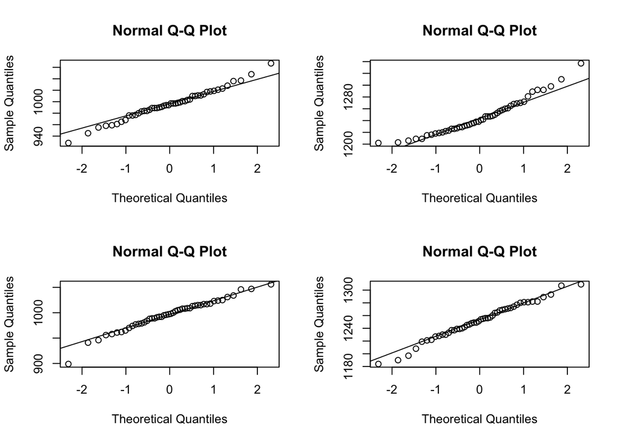

# 5 Distribution of Data

More visualizations were created to picture the distribution of the data.

## 5.1 Scatterplot

The scatter plot compared participants based on their mean reaction times across all conditions.

```r
tidied_data %>%
  ggplot(aes(x = participant, y = reaction_time)) + # Appoints x and y for plot
  stat_summary(fun = mean, geom = "point") + # Plot y with mean on scatter plot
  geom_smooth() + # Draws best fit line and standard error area
  labs(
    x = "Participants",
    y = "Mean Reaction Time (ms)",
    title = "Variation of Mean Reaction Time Within Participants"
  ) + # Edit labels
  theme(plot.title = element_text(hjust = .5)) # Moves plot along horizontal axis

# geom_smooth creates a LOESS best fit line by default and adds standard error based on a 95%
# confidence interval
```

The relatively flat best fit line and uniform shape of standard error across participants can signify that all participant’s reaction speeds are similar. This fits with what was observed during summary statistics 1 where mean and median reaction times within participants were similar across all participants.

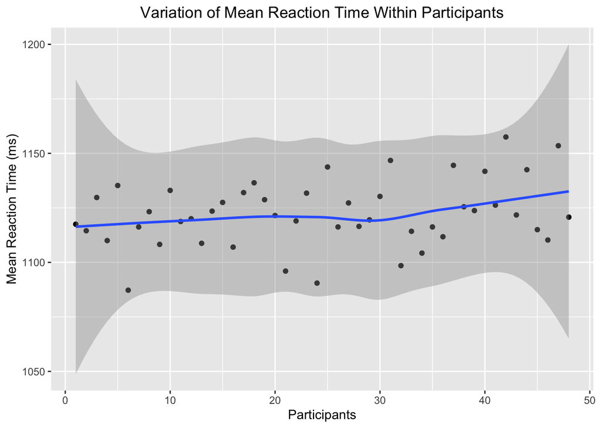

## 5.2 Kernel Density Plot

The kernel density plot similar to a histogram will look at the distribution based on frequency of reaction times. However, instead of counting discrete frequencies, densities are calculated for the probability the data points belong in a given area, thereby making it suitable for counting continuous data.

```r
tidied_data %>%
  ggplot(aes(x = reaction_time, fill = conditions)) + # Appoints the x and fill for plot
  geom_density(alpha = .5) + # Alpha changes transparency of plot
  labs(
    x = "Reaction Time (ms)",
    y = "Density",
    title = "Distribution of Reaction Times Accross Conditions"
  ) + # Edit labels
  theme(plot.title = element_text(hjust = .5)) # Moves plot along horizontal axis

# Fill is different from color only changing the color within the shape
# Color changes the outline as well
```

The plot demonstrates how both congruent conditions have very similar and lower reaction times compared to incongruent conditions. Inversely, both incongruent conditions have a similar and higher reaction time compared to congruent conditions.

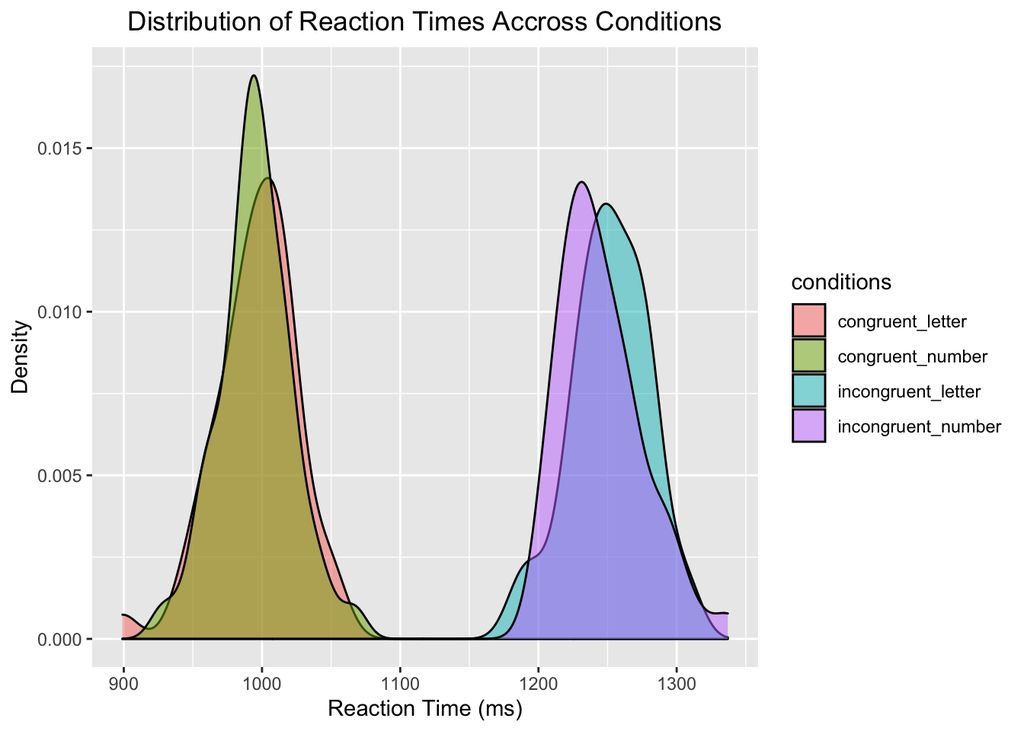

## 5.3 Dot Plot

The dot plot is used here to observe the distribution of reaction times for the different conditions. In the plot I added a line for standard deviation and rearranged for number condtions to beside each other, and letter conditions to be beside each other. The reason is to compare the difference between the incongruent and congruent conditions based on number or letter.

```r
tidied_data %>%
  ggplot(aes(x = conditions, y = reaction_time, fill = conditions)) + # Appoints x and y value
  #  and fill for plot
  geom_dotplot(
    binaxis = "y", # Group the y value in groups of discrete data points
    stackdir = "center", # Stack dots from the center
    stackratio = 1.5, # Changes how close dots stack
    dotsize = 0.5
  ) + # Changes size of dots
  stat_summary(
    fun.data = mean_sdl, # Plot standard deviation for y value
    geom = "pointrange", # Represent standard deviation with point range
    size = .5,
  ) + # Changes size of dot
  guides(fill = "none") + # Removes legend
  scale_x_discrete(limits = c(
    "incongruent_number", "congruent_number", "incongruent_letter", "congruent_letter"
  )) + # Reordering of values
  #  along x axis
  labs(
    x = "", # Left blank to remove label for x-axis
    y = "Reaction Time (ms)",
    title = "Dotplot of Reaction Time Accross Conditions"
  ) + # Changes labels
  theme(plot.title = element_text(hjust = .5)) # Move title along the horizontal axis
```

Through visual inspection, a clear lack of overlap between the standard deviation of condition groups show a definitive difference between the incongruent and congruent for both number and letters conditions.

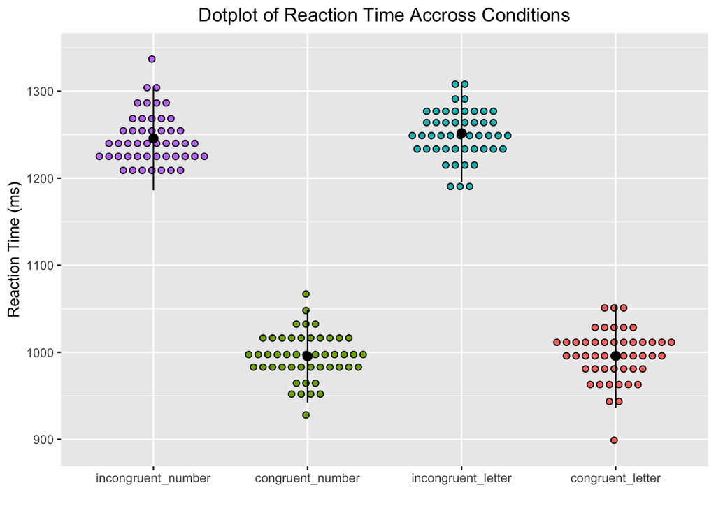